```python
import pandas as pd
import numpy as np
import matplotlib.pyplot as plt
import matplotlib.ticker as mtick
import seaborn as sns
from sklearn.preprocessing import MinMaxScaler
from sklearn.model_selection import train_test_split
from sklearn.linear_model import LogisticRegression
import warnings
from sklearn.metrics import confusion_matrix
from sklearn.feature_selection import RFE
from sklearn.metrics import accuracy_score
from sklearn.linear_model import LogisticRegressionCV
from sklearn.preprocessing import PolynomialFeatures
```

# Executive Summary

The aim of this report is to present a model that can predict probability of attrition of each employee and highlight variables that play the most important role with respect to attrition. The model is built using Logistic Regression with the aim of attaining optimal accuracy score on past data. The model can predict whether an employee would leave the company or not with 95.4% accuracy. Variables that impact the attrition rate are work accident, promotion last five years, department, satisfaction level, last evaluation, number of projects, average monthly hours, and time spend company. Each variable is further divided into range of scores and the model identifies which range of score impacts attrition the most.

# Data Loading

```python
raw_data= pd.read_csv("./turnover.csv",keep_default_na=False,na_values=['_'])
```

The dataset comprises of information about 15000 employees. Each employee record contains data for ten different information points. The first five columns are numeric columns, whereas the last five columns have either boolean values or strings. Columns with strings have salaries categorized in three levels, low, medium, and high, and departments categorized as ten different department names.

Summary statistics for every column is computed to understand the shape of data and detect presence of columns that have a relatively bigger scale. Number_project, Average_monthly_hours, and Time_spend_company are on a much larger scale compared to other columns, therefore, data will have to be scaled to a common range. Furthermore, data does not contain any Null values.

# Data preperation

```python
raw_data.head()
```

|  | satisfaction_level | last_evaluation | number_project | average_montly_hours | time_spend_company | Work_accident | left | promotion_last_5years | sales | salary |
| --- | --- | --- | --- | --- | --- | --- | --- | --- | --- | --- |
| 0 | 0.38 | 0.53 | 2 | 157 | 3 | 0 | 1 | 0 | sales | low |
| 1 | 0.80 | 0.86 | 5 | 262 | 6 | 0 | 1 | 0 | sales | medium |
| 2 | 0.11 | 0.88 | 7 | 272 | 4 | 0 | 1 | 0 | sales | medium |
| 3 | 0.72 | 0.87 | 5 | 223 | 5 | 0 | 1 | 0 | sales | low |
| 4 | 0.37 | 0.52 | 2 | 159 | 3 | 0 | 1 | 0 | sales | low |

```python
raw_data.describe()
```

|  | satisfaction_level | last_evaluation | number_project | average_montly_hours | time_spend_company | Work_accident | left | promotion_last_5years |
| --- | --- | --- | --- | --- | --- | --- | --- | --- |
| count | 14999.000000 | 14999.000000 | 14999.000000 | 14999.000000 | 14999.000000 | 14999.000000 | 14999.000000 | 14999.000000 |
| mean | 0.612834 | 0.716102 | 3.803054 | 201.050337 | 3.498233 | 0.144610 | 0.238083 | 0.021268 |
| std | 0.248631 | 0.171169 | 1.232592 | 49.943099 | 1.460136 | 0.351719 | 0.425924 | 0.144281 |
| min | 0.090000 | 0.360000 | 2.000000 | 96.000000 | 2.000000 | 0.000000 | 0.000000 | 0.000000 |
| 25% | 0.440000 | 0.560000 | 3.000000 | 156.000000 | 3.000000 | 0.000000 | 0.000000 | 0.000000 |
| 50% | 0.640000 | 0.720000 | 4.000000 | 200.000000 | 3.000000 | 0.000000 | 0.000000 | 0.000000 |
| 75% | 0.820000 | 0.870000 | 5.000000 | 245.000000 | 4.000000 | 0.000000 | 0.000000 | 0.000000 |
| max | 1.000000 | 1.000000 | 7.000000 | 310.000000 | 10.000000 | 1.000000 | 1.000000 | 1.000000 |

```python
raw_data.isnull().values.any()
```

```
False
```

The columns that were detected to have string, namely, salary and department column were divided into the number of unique strings present in each column. The salary column had three unique strings and the department column had ten unique strings.

In order to encode the columns that had strings, a custom function was used to detect categorical columns, divide them into the number of unique values found in every categorical column and replace the string with 1/0. This operation increased the number of columns from ten to twenty one.

```python
raw_data[['sales', 'salary']].describe().T
```

|  | count | unique | top | freq |
| --- | --- | --- | --- | --- |
| sales | 14999 | 10 | sales | 4140 |
| salary | 14999 | 3 | low | 7316 |

```python
transformed_data=raw_data.copy()
```

```python
def numerical_features(df):
    columns=df.columns
    return df._get_numeric_data().columns
```

```python
def categorical_features(df):
    numerical_columns=numerical_features(df)
    return(list(set(df.columns)-set(numerical_columns)))
```

```python
def onehot_encode(df):
    numericals = df.get(numerical_features(df))
    new_df = numericals.copy()
    for categorical_column in categorical_features(df):
        new_df = pd.concat([new_df,
                            pd.get_dummies(df[categorical_column],
                                           prefix=categorical_column)],
                           axis=1)
    return new_df
```

```python
numerical_features(transformed_data)
```

```
Index(['satisfaction_level', 'last_evaluation', 'number_project',
       'average_montly_hours', 'time_spend_company', 'Work_accident', 'left',
       'promotion_last_5years'],
      dtype='object')
```

```python
categorical_features(transformed_data)
```

```
['salary', 'sales']
```

```python
transformed_data=onehot_encode(transformed_data)
```

Summary statistics on the data set showed that numerical columns did not have a compatible scale. Some columns had values between zero and one, whereas, other columns had values in hundreds. In order to standardize the scale of numerical columns, python’s built-in MinMaxScaler function was used on the following columns: satisfaction_level, last_evaluation, number_project, average_montly_hours, and time_spend_company.

```python
scaler = MinMaxScaler()
transformed_data[['satisfaction_level','last_evaluation','number_project',
                  'average_montly_hours','time_spend_company']] = scaler.fit_transform(
                   transformed_data[['satisfaction_level','last_evaluation','number_project',
                  'average_montly_hours','time_spend_company']])
```

```python
transformed_data.columns
```

```
Index(['satisfaction_level', 'last_evaluation', 'number_project',
       'average_montly_hours', 'time_spend_company', 'Work_accident', 'left',
       'promotion_last_5years', 'salary_high', 'salary_low', 'salary_medium',
       'sales_IT', 'sales_RandD', 'sales_accounting', 'sales_hr',
       'sales_management', 'sales_marketing', 'sales_product_mng',
       'sales_sales', 'sales_support', 'sales_technical'],
      dtype='object')
```

The datatype of every column was checked with a python built-in function ‘dtypes’. Upon inspection, it was found that all the columns with boolean values were either ‘int64’ or ‘uint8’. In order to fix the data type of miscategorized columns, panda’s ‘categorical’ function was used.

```python
for i in transformed_data.columns:
    print(transformed_data.dtypes[i])
```

```
float64
float64
float64
float64
float64
int64
int64
int64
uint8
uint8
uint8
uint8
uint8
uint8
uint8
uint8
uint8
uint8
uint8
uint8
uint8
```

```python
for i in transformed_data.columns:
    if transformed_data.dtypes[i]=='int64' or transformed_data.dtypes[i]=='uint8':
        transformed_data[i] = pd.Categorical(transformed_data[i])
```

```python
for i in transformed_data.columns:
    print(transformed_data.dtypes[i])
```

```
float64
float64
float64
float64
float64
category
category
category
category
category
category
category
category
category
category
category
category
category
category
category
category
```

# Data Exploration

```python
transformed_data.head()
```

|  | satisfaction_level | last_evaluation | number_project | average_montly_hours | time_spend_company | Work_accident | left | promotion_last_5years | salary_high | salary_low | ... | sales_IT | sales_RandD | sales_accounting | sales_hr | sales_management | sales_marketing | sales_product_mng | sales_sales | sales_support | sales_technical |
| --- | --- | --- | --- | --- | --- | --- | --- | --- | --- | --- | --- | --- | --- | --- | --- | --- | --- | --- | --- | --- | --- |
| 0 | 0.318681 | 0.265625 | 0.0 | 0.285047 | 0.125 | 0 | 1 | 0 | 0 | 1 | ... | 0 | 0 | 0 | 0 | 0 | 0 | 0 | 1 | 0 | 0 |
| 1 | 0.780220 | 0.781250 | 0.6 | 0.775701 | 0.500 | 0 | 1 | 0 | 0 | 0 | ... | 0 | 0 | 0 | 0 | 0 | 0 | 0 | 1 | 0 | 0 |
| 2 | 0.021978 | 0.812500 | 1.0 | 0.822430 | 0.250 | 0 | 1 | 0 | 0 | 0 | ... | 0 | 0 | 0 | 0 | 0 | 0 | 0 | 1 | 0 | 0 |
| 3 | 0.692308 | 0.796875 | 0.6 | 0.593458 | 0.375 | 0 | 1 | 0 | 0 | 1 | ... | 0 | 0 | 0 | 0 | 0 | 0 | 0 | 1 | 0 | 0 |
| 4 | 0.307692 | 0.250000 | 0.0 | 0.294393 | 0.125 | 0 | 1 | 0 | 0 | 1 | ... | 0 | 0 | 0 | 0 | 0 | 0 | 0 | 1 | 0 | 0 |

5 rows × 21 columns

The red bars in the graph below show that for a particular satisfaction level, more people leave the company than those who stay. Without going into details, it can be observed that most employees with low satisfaction levels and mid range scores for satisfaction leave the company.

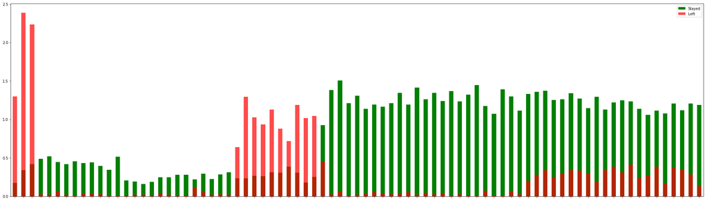

```python
ax=pd.Series((transformed_data[transformed_data.left==0].satisfaction_level.value_counts()/len(transformed_data.left))*100).sort_index().plot(kind='bar',color='g',figsize=(35,10))
pd.Series((transformed_data[transformed_data.left==1].satisfaction_level.value_counts()/len(transformed_data.left))*100).sort_index().plot(kind='bar', color='r',alpha= 0.7,figsize=(35,10), ax=ax)
ax.legend(["Stayed", "Left"])
ax.xaxis.set_major_formatter(plt.NullFormatter())
plt.savefig("satisfaction_level.png")
```

Similarly, for last evaluation scores, from the employees who were evaluated poorly, a lot more left the company than those who stayed back. Average last evaluation score also resulted in attritions but the number was not as big as for those who had low last evaluation scores.

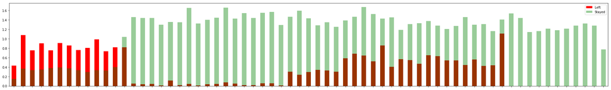

```python
ax=((transformed_data[transformed_data.left==1].last_evaluation.value_counts().sort_index()/len(transformed_data.left))*100).plot(kind='bar',color='r',figsize=(35,5))
((transformed_data[transformed_data.left==0].last_evaluation.value_counts().sort_index()/len(transformed_data.left))*100).plot(kind='bar',color='g',alpha=0.4,figsize=(35,5),ax=ax)
ax.legend(["Left", "Stayed"])
ax.xaxis.set_major_formatter(plt.NullFormatter())
plt.savefig("Last_Evaluation.png")
```

The graph shows that fewer employees stay with the company for number of projects score of 0,4, and 5 than employees who leave the company.

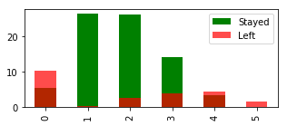

```python
ax=((transformed_data[transformed_data.left==0].number_project.value_counts().sort_index()/len(transformed_data.left))*100).plot(kind='bar',color='g',figsize=(5,2))
((transformed_data[transformed_data.left==1].number_project.value_counts().sort_index()/len(transformed_data.left))*100).plot(kind='bar',color='r',alpha=0.7,figsize=(5,2),ax=ax)
ax.legend(["Stayed", "Left"])
ax.xaxis.set_major_formatter(mtick.ScalarFormatter())
plt.savefig("Number_Projects.png")
```

The red bars in the graph below show that for a particular number of monthly hours, more people leave the company than those who stay. Without going into details, it can be observed that most employees who work less hours leave the company. Whereas, for hours in the mid range, attritions are less than number of employees who stay with the company.

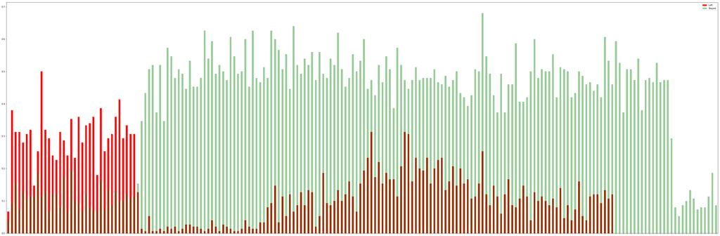

```python
ax=((transformed_data[transformed_data.left==1].average_montly_hours.value_counts().sort_index()/len(transformed_data.left))*100).plot(kind='bar',color='r',figsize=(60,20))
((transformed_data[transformed_data.left==0].average_montly_hours.value_counts().sort_index()/len(transformed_data.left))*100).plot(kind='bar',color='g',alpha=0.4,figsize=(60,20),ax=ax)
ax.legend(["Left", "Stayed"])
ax.xaxis.set_major_formatter(plt.NullFormatter())
plt.savefig("Average_Monthly_Hours.png")
```

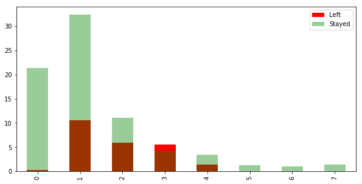

```python
ax=((transformed_data[transformed_data.left==1].time_spend_company.value_counts().sort_index()/len(transformed_data.left))*100).plot(kind='bar',color='r',figsize=(10,5))
((transformed_data[transformed_data.left==0].time_spend_company.value_counts().sort_index()/len(transformed_data.left))*100).plot(kind='bar',color='g',alpha=0.4,figsize=(10,5),ax=ax)
ax.legend(["Left", "Stayed"])
ax.xaxis.set_major_formatter(mtick.ScalarFormatter())
plt.savefig("Time_Spend_Company.png")
```

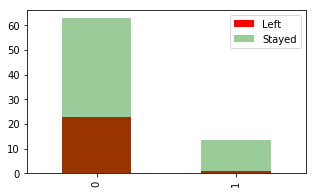

```python
ax=((transformed_data[transformed_data.left==1].Work_accident.value_counts().sort_index()/len(transformed_data.left))*100).plot(kind='bar',color='r',figsize=(5,3))
((transformed_data[transformed_data.left==0].Work_accident.value_counts().sort_index()/len(transformed_data.left))*100).plot(kind='bar',color='g',alpha=0.4,figsize=(5,3),ax=ax)
ax.legend(["Left", "Stayed"])
ax.xaxis.set_major_formatter(mtick.ScalarFormatter())
plt.savefig("Work_Accident.png")
```

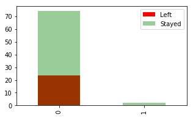

```python
ax=((transformed_data[transformed_data.left==1].promotion_last_5years.value_counts().sort_index()/len(transformed_data.left))*100).plot(kind='bar',color='r',figsize=(5,3))
((transformed_data[transformed_data.left==0].promotion_last_5years.value_counts().sort_index()/len(transformed_data.left))*100).plot(kind='bar',color='g',alpha=0.4,figsize=(5,3),ax=ax)
ax.legend(["Left", "Stayed"])
ax.xaxis.set_major_formatter(mtick.ScalarFormatter())
plt.savefig("Promotion.png")
```

# Baseline Model

At this point, the transformed data was used to build a baseline model. Python’s built-in ‘LogisticRegressionCV’ function was used with k=5. The value of K was chosen to be 5 in order to have a 80/20 split between train and test data in each iteration. The mean accuracy score was **78.4**.

```python
Explanatory = transformed_data.loc[:, transformed_data.columns != 'left']
Target = np.ravel(transformed_data.loc[:, transformed_data.columns == 'left'])
```

```python
Model=LogisticRegressionCV(cv=5).fit(Explanatory,Target)
Model.score(Explanatory,Target)
```

```
0.7845856390426028
```

# Feature Engineering

Findings from the data exploration exercise formed the basis for feature engineering. Columns were binned according to pattern in the graphs. For example, employees who scored their satisfaction between 0.0 and 0.022 left the company, therefore a seperate column was made for employees with satisfaction level between 0.0 and 0.22 and filled with

0/1 implying whether an employee stayed or left. Following functions were defined to bin and dummify the columns:

**Sats_trans:** Binned satisfaction level as follows: [0.0, 0.022, 0.286, 0.396, 0.91]. Dummified each column and dropped the original satisfaction level column

```python
def sats_trans(df):
    bins = [0.0, 0.021978021978021983, 0.28571428571428564, 0.3956043956043956, 0.9120879120879121]
    df['satisfaction_level_bin'] = pd.cut(df.satisfaction_level,bins)
    df = pd.concat([df, pd.get_dummies(df['satisfaction_level_bin'],prefix='sts', prefix_sep='_')], axis=1)
    df.drop('satisfaction_level', inplace=True, axis=1)
    df.drop('satisfaction_level_bin', inplace=True, axis=1)
    return df
```

**Eval_trans:** Binned ‘Last evaluation’ column as follows: [0.0,0.171875,0.453125,0.828125,1.0]. Dummified each column and dropped the original ‘Last evaluation’ column.

```python
def eval_trans(df):
    #df=sats_trans(df)
    bins = [0.0,0.171875,0.453125,0.828125,1.0]
    df['last_evaluation_bin'] = pd.cut(df.last_evaluation,bins)

    df= pd.concat([df, pd.get_dummies(df['last_evaluation_bin'],prefix='le', prefix_sep='_')], axis=1)
    df.drop('last_evaluation_bin', inplace=True, axis=1)
    df.drop('last_evaluation', inplace=True, axis=1)
    return df
```

**Proj_trans:** Replaced the numerical values in ‘Number of Projects’ column with the dictionary values mentioned below and dummified the column as per the labels. For example, all the employees with low number of projects had 1’s for low and 0’s for medium, high, and very high. dict = { 0.20000000000000007: "low", 0.4 : "medium", 0.6 : "medium", 0.8000000000000002: "high", 0.0: "high", 1: "Very high"}

```python
def proj_trans(df):
    #df=eval_trans(df)
    lkup = { 0.20000000000000007: "low", 0.4 : "medium", 0.6 : "medium",  0.8000000000000002: "high", 0.0: "high", 1: "Very high"}
    df['number_project_cat'] = df['number_project'].map(lkup)

    df = pd.concat([df, pd.get_dummies(df['number_project_cat'],prefix='np', prefix_sep='_')], axis=1)
    df.drop('number_project_cat', inplace=True, axis=1)
    df.drop('number_project', inplace=True, axis=1)
    return df
```

**Hour_trans:** Binned ‘Average monthly hours’ columns as follows: [0.0, 0.1589, 0.322, 0.7617,0.8925]. Dummified each column and dropped the original ‘Average monthly hours’ column.

```python
def hour_trans(df):
    #df=proj_trans(df)
    bins = [0.0, 0.15887850467289721, 0.32242990654205606, 0.7616822429906541,0.8925233644859812]
    df['average_montly_hours_bin'] = pd.cut(df.average_montly_hours,bins)
    df = pd.concat([df, pd.get_dummies(df['average_montly_hours_bin'],prefix='am', prefix_sep='_')], axis=1)
    df.drop('average_montly_hours_bin', inplace=True, axis=1)
    df.drop('average_montly_hours', inplace=True, axis=1)
    return df
```

**Year_trans:** Replaced the numerical values in ‘Time spend company’ column with the dictionary values mentioned below and dummified the column as per the labels. For example, all the employees with low time spend company had 1’s for low and 0’s for very low, medium, and high. dict = { 0.0: "low", 0.125 : "medium", 0.25 : "medium", 0.5 : "medium", 0.375: "high", 0.625: "very low", 0.75: "very low", 1.0: "very low"}

```python
def year_trans(df):
    #df=hour_trans(df)
    lkup = { 0.0: "low", 0.125 : "medium", 0.25 : "medium", 0.5 : "medium", 0.375: "high", 0.625: "very low", 0.75: "very low", 1.0: "very low"}
    df['time_spend_company_cat'] = df['time_spend_company'].map(lkup)
    df= pd.concat([df, pd.get_dummies(df['time_spend_company_cat'],prefix='tsc', prefix_sep='_')], axis=1)
    df.drop('time_spend_company_cat', inplace=True, axis=1)
    df.drop('time_spend_company', inplace=True, axis=1)
    return df
```

After all the transformations were accepted, engineered dataset was used for Logistic regression with five fold cross validation. Accuracy score for the engineered data was **93.2%**, which is a **14.8 points** increase over the baseline model.

```python
def feature_engineering_pipeline(raw_data, fe_functions):
    selected_functions = []
    base_score = score_model(raw_data)
    print('Base Score: {:.4f}'.format(base_score))
    engineered_data = raw_data.copy()
    for fe_function in fe_functions:
        processed_data = globals()[fe_function](engineered_data)
        new_score = score_model(processed_data)
        print('- New Score ({}): {:.4f} '.format(fe_function, new_score),
              end='')
        difference = (new_score-base_score)
        print('[diff: {:.4f}] '.format(difference), end='')
        if difference > -0.01:
            selected_functions.append(fe_function)
            engineered_data = processed_data.copy()
            base_score = new_score
            print('[Accepted]')
        else:
            print('[Rejected]')
    return selected_functions,engineered_data
```

```python
def score_model(data, seed=666):

    X = transformed_data.loc[:, transformed_data.columns !='left']
    test = np.ravel(transformed_data.loc[:, transformed_data.columns == 'left'])

    X_train, X_test, y_train, y_test = train_test_split(X, test,
                                                        test_size=0.20,
                                                        random_state=seed)

    # Create Logistic regression object
    regr = LogisticRegression()
    regr.fit(X_train, y_train)
    y_pred = regr.predict(X_test)
    return accuracy_score(y_test,y_pred)
```

```python
fe_functions=['sats_trans','eval_trans','proj_trans','hour_trans','year_trans']
```

```python
funcs, new_dataset = feature_engineering_pipeline(transformed_data, fe_functions)
```

```
Base Score: 0.7887
- New Score (sats_trans): 0.7887 [diff: 0.0000] [Accepted]
- New Score (eval_trans): 0.7887 [diff: 0.0000] [Accepted]
- New Score (proj_trans): 0.7887 [diff: 0.0000] [Accepted]
- New Score (hour_trans): 0.7887 [diff: 0.0000] [Accepted]
- New Score (year_trans): 0.7887 [diff: 0.0000] [Accepted]
```

```python
Expl = new_dataset.loc[:, new_dataset.columns != 'left']
Tar = np.ravel(new_dataset.loc[:, new_dataset.columns == 'left'])
```

```python
Model=LogisticRegressionCV(cv=5).fit(Expl,Tar)
Model.score(Expl,Tar)
```

```
0.9319287952530169
```

# Feature Selection

```python
nof_list=np.arange(1,41)
high_score=0
#Variable to store the optimum features
nof=0
score_list =[]
for n in range(len(nof_list)):
    X_train, X_test, y_train, y_test = train_test_split(Expl,Tar, test_size = 0.3, random_state = 0)
    model = LogisticRegression()
    rfe = RFE(model,nof_list[n])
    X_train_rfe = rfe.fit_transform(X_train,y_train)
    X_test_rfe = rfe.transform(X_test)
    model.fit(X_train_rfe,y_train)
    score = model.score(X_test_rfe,y_test)
    score_list.append(score)
    if(score>high_score):
        high_score = score
        nof = nof_list[n]
print("Optimum number of features: %d" %nof)
print("Score with %d features: %f" % (nof, high_score))
warnings.simplefilter(action='ignore')
```

```
Optimum number of features: 22
Score with 22 features: 0.936222
```

```python
cols = list(Expl.columns)
model = LogisticRegression()
#Initializing RFE model
rfe = RFE(model, 22)
#Transforming data using RFE
X_rfe = rfe.fit_transform(Expl,Tar)
#Fitting the data to model
model.fit(X_rfe,Tar)
temp = pd.Series(rfe.support_,index = cols)
selected_features_rfe = temp[temp==True].index
print(selected_features_rfe)
```

```
Index(['Work_accident', 'promotion_last_5years', 'salary_high', 'salary_low',
       'sales_RandD', 'sts_(0.0, 0.022]', 'sts_(0.022, 0.286]',
       'sts_(0.286, 0.396]', 'le_(0.172, 0.453]', 'le_(0.453, 0.828]',
       'le_(0.828, 1.0]', 'np_Very high', 'np_low', 'np_medium',
       'am_(0.0, 0.159]', 'am_(0.159, 0.322]', 'am_(0.322, 0.762]',
       'am_(0.762, 0.893]', 'tsc_high', 'tsc_low', 'tsc_medium',
       'tsc_very low'],
      dtype='object')
```

# Polynomial Features

Finally, after reducing the dataset to 22 features, polynomial features with a degree of 2 were computed for every variable. Dataset with polynomials was used for modelling with five fold cross validation, which produced an accuracy of **95.4%**.

```python
final_data=Expl[selected_features_rfe]
```

```python
pol = PolynomialFeatures(2)
X_polynomial=pol.fit_transform(final_data.as_matrix())
```

```python
Model=LogisticRegressionCV(cv=5).fit(X_polynomial,Tar)
Model.score(X_polynomial,Tar)
```

```
0.9541969464630975
```